# Frequentist and Bayesian random effects models in R: an RStan tutorial

Amanda Koepke

1/11/2022

RStan is the R interface to Stan. For more information on Stan and its modeling language visit the Stan website at http://mc-stan.org/

Stan uses Hamiltonian Monte Carlo, which provides a very efficient way to explore the posterior distribution and allows for the most natural definition of specialized probability distributions.

## Getting started

Detailed instructions here: http://mc-stan.org/rstan/

Tells you how to download

## How to Use RStan

```r
library("rstan") # observe startup messages
options(mc.cores = parallel::detectCores()) # if you are using rstan locally on a multicore machine and have plenty of RAM to estimate your model in parallel, this is helpful
rstan_options(auto_write = TRUE) #allows you to automatically save a bare version of a compiled Stan program to the hard disk so that it does not need to be recompiled (unless you change it).
```

You will need to run these commands each time you load the rstan library.

## Example 1: Basic Example

We start by writing a Stan program for the model in a text file. If you are using RStudio version 1.2.x or greater, click on File -> New File -> Stan File. Otherwise, open your favorite text editor.

```r
mu=10
sigma=5
N=10

y=rnorm(N,mu,sigma)

basicEx_dat=list(y=y,N=N)

fit_basic <- stan(file = 'basicEx.stan', data = basicEx_dat,
                  iter = 2000,warmup = 2000/2,chains=4)

print(fit_basic)
```

```
## Inference for Stan model: basicEx.
## 4 chains, each with iter=2000; warmup=1000; thin=1;
## post-warmup draws per chain=1000, total post-warmup draws=4000.
##
##         mean se_mean   sd   2.5%    25%    50%    75%  97.5% n_eff Rhat
## mu     10.06    0.05 1.96   6.23   8.90  10.03  11.17  13.98  1382    1
## sigma   5.86    0.05 1.91   3.50   4.61   5.43   6.62  10.42  1403    1
## lp__  -20.04    0.04 1.20 -23.08 -20.52 -19.66 -19.20 -18.92  1071    1
##
## Samples were drawn using NUTS(diag_e) at Tue Jan 11 15:00:00 2022.
## For each parameter, n_eff is a crude measure of effective sample size,
## and Rhat is the potential scale reduction factor on split chains (at
## convergence, Rhat=1).
```

### Posterior summary statistics and convergence diagnostics

From: https://cran.r-project.org/web/packages/rstan/vignettes/stanfit-objects.html

```r
### look at summary stats
fit_basic_summary <- summary(fit_basic)
print(names(fit_basic_summary))
```

```
## [1] "summary"   "c_summary"
```

In fit_summary$summary all chains are merged whereas fit_summary$c_summary contains summaries for each chain individually. Typically we want the summary for all chains merged, which is what we’ll focus on here.

The summary is a matrix with rows corresponding to parameters and columns to the various summary quantities. These include the posterior mean, the posterior standard deviation, and various quantiles computed from the draws. The probs argument can be used to specify which quantiles to compute and pars can be used to specify a subset of parameters to include in the summary.

If, for example, we wanted the only quantiles included to be 2.5% and 97.5%, and for only the parameters included to be mu and sigma, we would specify that like this:

```r
mu_sigma_summary <- summary(fit_basic, pars = c("mu", "sigma"), probs = c(0.025, 0.975))$summary
print(mu_sigma_summary)
```

```
##            mean    se_mean       sd     2.5%    97.5%    n_eff     Rhat
## mu    10.059666 0.05266545 1.958198 6.230965 13.97799 1382.489 1.000495
## sigma  5.857491 0.05096366 1.908894 3.503915 10.42450 1402.951 1.000083
```

For models fit using MCMC, also included in the summary are the Monte Carlo standard error (se_mean), the effective sample size (n_eff), and the R-hat statistic (Rhat).

From https://mc-stan.org/rstan/reference/Rhat.html:

“The Rhat function produces R-hat convergence diagnostic, which compares the between- and within-chain estimates for model parameters and other univariate quantities of interest. If chains have not mixed well (ie, the between- and within-chain estimates don’t agree), R-hat is larger than 1. We recommend running at least four chains by default and only using the sample if R-hat is less than 1.05.”

```r
###look at posterior draws
basicEx_posteriorDraws <- extract(fit_basic) ## provides list
print(names(basicEx_posteriorDraws))
```

```
## [1] "mu"    "sigma" "lp__"
```

```r
basicEx_posteriorDraws_DF <- as.data.frame(fit_basic) ## provides df
head(basicEx_posteriorDraws_DF)
```

```
##          mu    sigma      lp__
## 1 10.982161 6.335876 -19.47547
## 2 10.236447 7.547752 -20.13169
## 3  9.452673 6.405045 -19.44576
## 4  9.730917 7.141147 -19.86618
## 5  5.847932 6.636714 -21.53420
## 6 10.467925 7.230233 -19.93286
```

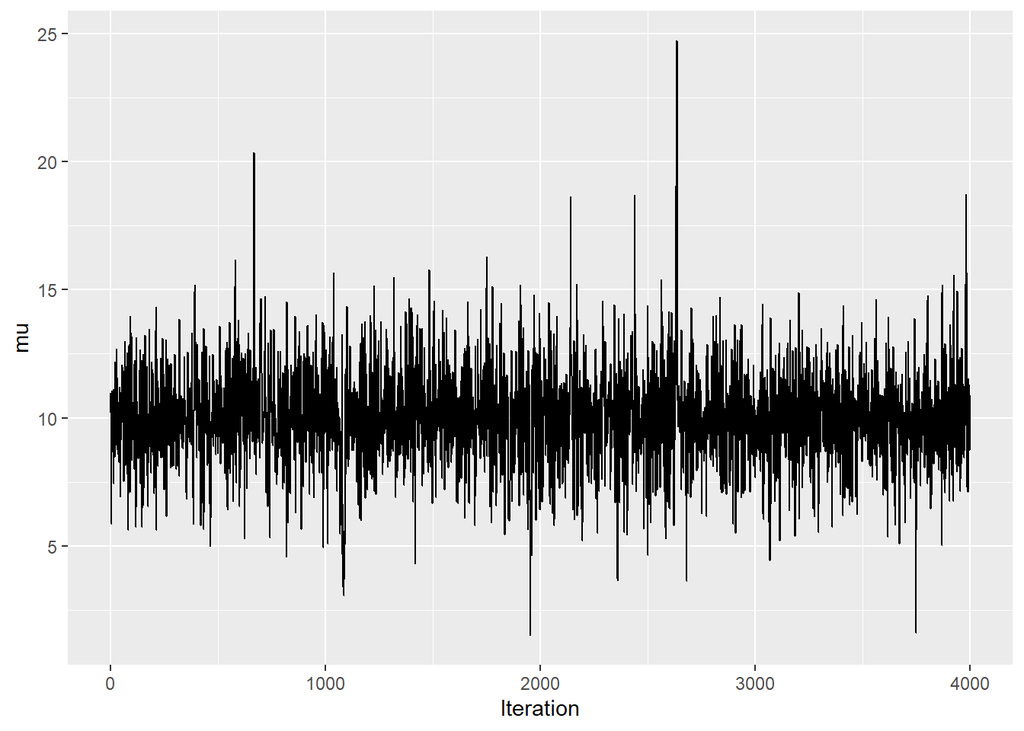

```r
basicEx_posteriorDraws_DF$Iteration=1:4000

# Trace plot
ggplot(basicEx_posteriorDraws_DF,aes(Iteration, mu))+
  geom_line()
```

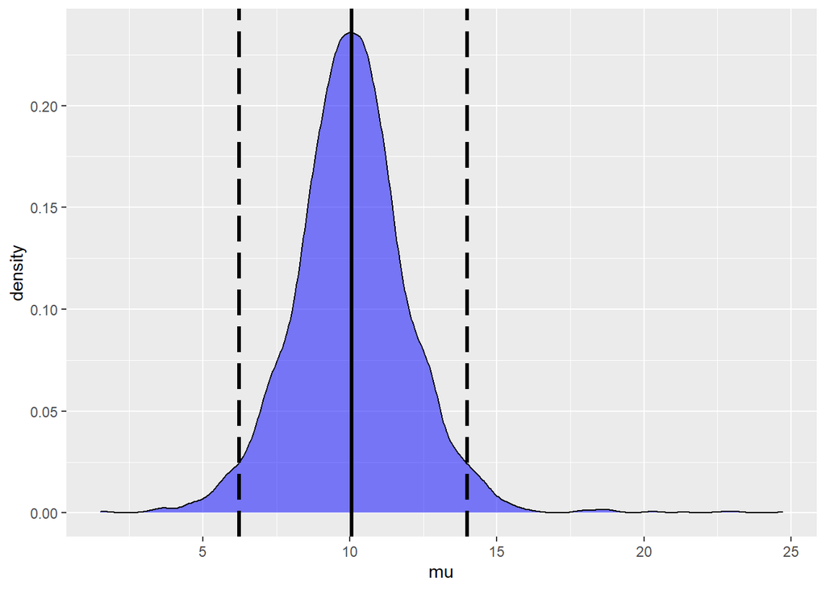

```r
# Posterior Distribution
ggplot(basicEx_posteriorDraws_DF,aes(mu))+
  geom_density(fill="blue", alpha=0.5)+
  geom_vline(xintercept = mu_sigma_summary["mu","mean"],size=1.2)+
  geom_vline(xintercept = mu_sigma_summary["mu",c("2.5%","97.5%")],linetype="longdash",size=1.2)
```

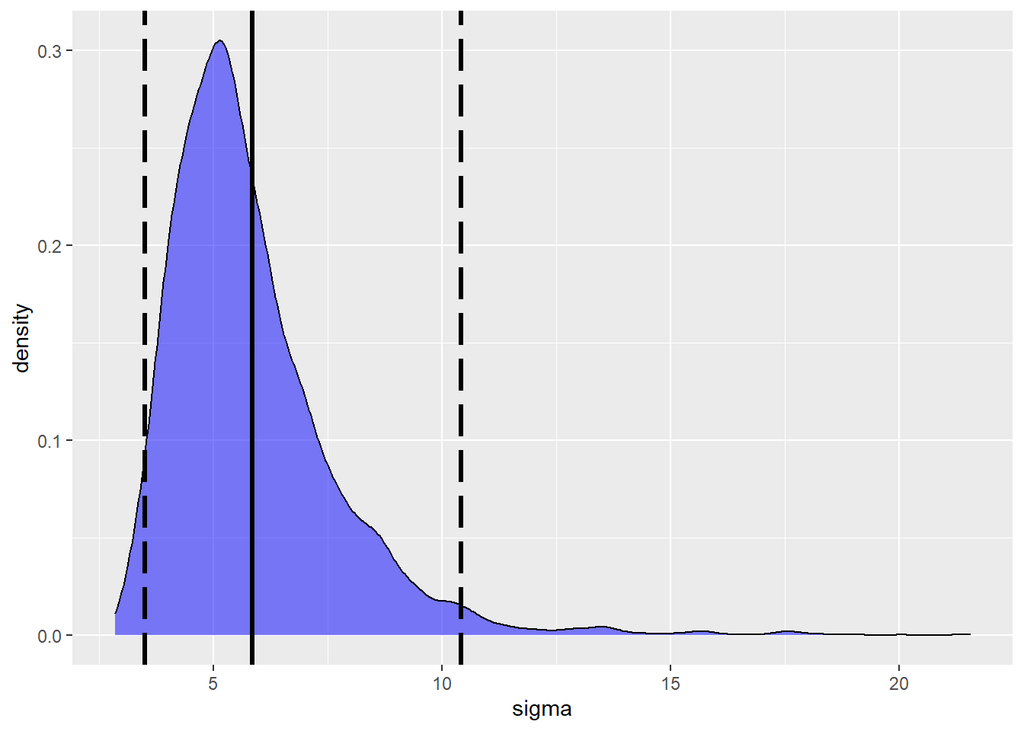

```r
ggplot(basicEx_posteriorDraws_DF,aes(sigma))+
  geom_density(fill="blue", alpha=0.5)+
  geom_vline(xintercept = mu_sigma_summary["sigma","mean"],size=1.2)+
  geom_vline(xintercept = mu_sigma_summary["sigma",c("2.5%","97.5%")],linetype="longdash",size=1.2)
```

## Example 2: Eight Schools

This is an example in Section 5.5 of Gelman et al (2003), which studied coaching effects from eight schools. For simplicity, we call this example “eight schools.”

```r
schools_dat <- list(J = 8,
                    y = c(28,  8, -3,  7, -1,  1, 18, 12),
                    sigma = c(15, 10, 16, 11,  9, 11, 10, 18))

fit_schools <- stan(file = 'schools.stan', data = schools_dat)
print(fit_schools)
```

```
## Inference for Stan model: schools.
## 4 chains, each with iter=2000; warmup=1000; thin=1;
## post-warmup draws per chain=1000, total post-warmup draws=4000.
##
##             mean se_mean   sd   2.5%    25%    50%    75% 97.5% n_eff Rhat
## mu          4.47    0.16 3.30  -1.82   2.34   4.40   6.70 11.24   413 1.01
## tau         3.91    0.18 2.97   0.77   1.79   3.08   5.16 11.65   277 1.01
## lambda[1]   6.34    0.21 5.57  -3.19   2.82   5.73   9.24 19.50   682 1.01
## lambda[2]   5.18    0.17 4.73  -3.76   2.33   5.02   8.00 14.91   808 1.01
## lambda[3]   3.90    0.18 5.31  -7.69   1.17   4.03   6.95 13.86   850 1.01
## lambda[4]   4.93    0.15 4.83  -4.61   2.04   4.75   7.78 14.79   999 1.00
## lambda[5]   3.64    0.18 4.67  -6.51   0.91   3.98   6.58 12.37   683 1.01
## lambda[6]   4.27    0.18 4.96  -6.35   1.51   4.34   7.23 14.00   785 1.01
## lambda[7]   6.55    0.20 5.04  -2.19   3.28   5.99   9.42 17.96   660 1.01
## lambda[8]   4.87    0.18 5.27  -5.63   1.97   4.73   7.88 15.17   878 1.01
## lp__      -15.45    0.44 5.56 -26.31 -19.35 -15.45 -11.41 -5.21   162 1.01
##
## Samples were drawn using NUTS(diag_e) at Tue Jan 11 15:00:06 2022.
## For each parameter, n_eff is a crude measure of effective sample size,
## and Rhat is the potential scale reduction factor on split chains (at
## convergence, Rhat=1).
```

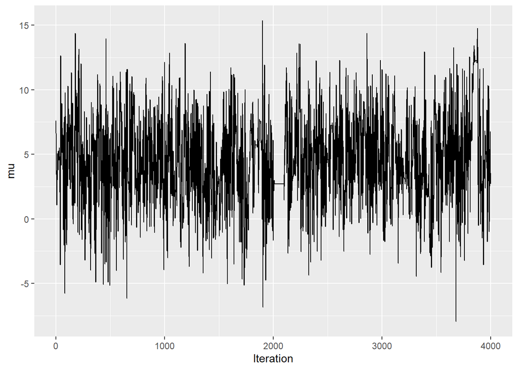

```r
schools_posteriorDraws_DF <- as.data.frame(fit_schools) ## provides df
schools_posteriorDraws_DF$Iteration=1:4000

# Trace plot
ggplot(schools_posteriorDraws_DF,aes(Iteration, mu))+
  geom_line()
```

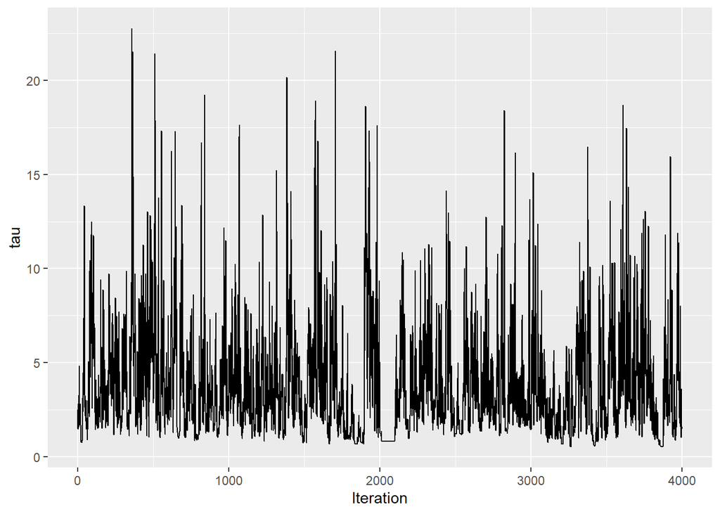

```r
ggplot(schools_posteriorDraws_DF,aes(Iteration, tau))+
  geom_line()
```

From https://mc-stan.org/users/documentation/case-studies/divergences_and_bias.html

“Unfortunately, this direct implementation of the model exhibits a pathological geometry that frustrates geometric ergodicity.”

## Example 2: reparameterization of 8 schools

In a non-centered parameterization we do not try to fit the group-level parameters directly, rather we fit a latent Gaussian variable from which we can recover the group-level parameters with a scaling and a translation.

```r
better_fit_schools <- stan(file = 'betterSchools.stan', data = schools_dat,iter=11000, warmup=1000)
```

```
## Warning: There were 18 divergent transitions after warmup. See
## http://mc-stan.org/misc/warnings.html#divergent-transitions-after-warmup
## to find out why this is a problem and how to eliminate them.
```

```
## Warning: Examine the pairs() plot to diagnose sampling problems
```

```r
print(better_fit_schools)
```

```
## Inference for Stan model: betterSchools.
## 4 chains, each with iter=11000; warmup=1000; thin=1;
## post-warmup draws per chain=10000, total post-warmup draws=40000.
##
##                  mean se_mean   sd   2.5%   25%   50%   75% 97.5% n_eff Rhat
## mu               4.38    0.02 3.32  -2.26  2.18  4.41  6.62 10.81 38511    1
## tau              3.62    0.02 3.26   0.12  1.26  2.77  5.00 12.04 25712    1
## lambda_tilde[1]  0.31    0.00 0.99  -1.67 -0.34  0.33  0.98  2.22 40958    1
## lambda_tilde[2]  0.10    0.00 0.94  -1.79 -0.52  0.11  0.73  1.95 41805    1
## lambda_tilde[3] -0.08    0.00 0.97  -1.99 -0.73 -0.08  0.56  1.82 42615    1
## lambda_tilde[4]  0.06    0.00 0.94  -1.80 -0.56  0.07  0.69  1.90 42854    1
## lambda_tilde[5] -0.16    0.00 0.93  -1.98 -0.78 -0.15  0.45  1.70 43338    1
## lambda_tilde[6] -0.07    0.00 0.93  -1.91 -0.69 -0.06  0.55  1.78 40964    1
## lambda_tilde[7]  0.36    0.00 0.96  -1.57 -0.26  0.38  1.01  2.19 39153    1
## lambda_tilde[8]  0.08    0.00 0.97  -1.84 -0.56  0.08  0.72  1.97 42392    1
## lambda[1]        6.20    0.03 5.65  -3.28  2.76  5.61  8.83 19.85 35700    1
## lambda[2]        4.89    0.02 4.64  -4.24  2.07  4.84  7.66 14.45 43337    1
## lambda[3]        3.95    0.03 5.28  -7.59  1.12  4.18  7.13 13.72 37657    1
## lambda[4]        4.75    0.02 4.78  -4.83  1.87  4.72  7.57 14.58 41237    1
## lambda[5]        3.62    0.02 4.67  -6.62  0.90  3.88  6.63 12.12 43533    1
## lambda[6]        4.03    0.02 4.83  -6.28  1.24  4.22  7.07 13.14 39086    1
## lambda[7]        6.30    0.03 5.09  -2.51  3.03  5.85  8.98 18.15 36921    1
## lambda[8]        4.85    0.03 5.31  -5.60  1.79  4.76  7.75 15.99 36834    1
## lp__            -6.93    0.02 2.36 -12.44 -8.29 -6.60 -5.20 -3.29 16489    1
##
## Samples were drawn using NUTS(diag_e) at Tue Jan 11 15:00:13 2022.
## For each parameter, n_eff is a crude measure of effective sample size,
## and Rhat is the potential scale reduction factor on split chains (at
## convergence, Rhat=1).
```

## Dealing with warnings

```r
better_fit_schools <- stan(file = 'betterSchools.stan', data = schools_dat,iter=11000, warmup=1000,control=list(adapt_delta=0.90))
```

```
## Warning in readLines(file, warn = TRUE): incomplete final line found on 'C:
## \Users\Amanda Koepke\Documents\betterSchools.stan'
```

```r
print(better_fit_schools)
```

```
## Inference for Stan model: betterSchools.
## 4 chains, each with iter=11000; warmup=1000; thin=1;
## post-warmup draws per chain=10000, total post-warmup draws=40000.
##
##                  mean se_mean   sd   2.5%   25%   50%   75% 97.5% n_eff Rhat
## mu               4.40    0.02 3.32  -2.12  2.18  4.41  6.63 10.81 40477    1
## tau              3.63    0.02 3.24   0.12  1.27  2.77  5.00 12.10 30453    1
## lambda_tilde[1]  0.32    0.00 0.99  -1.67 -0.35  0.34  1.00  2.22 44504    1
## lambda_tilde[2]  0.10    0.00 0.93  -1.75 -0.52  0.11  0.73  1.91 46373    1
## lambda_tilde[3] -0.08    0.00 0.97  -1.98 -0.73 -0.09  0.56  1.85 49910    1
## lambda_tilde[4]  0.06    0.00 0.94  -1.81 -0.57  0.06  0.68  1.91 53112    1
## lambda_tilde[5] -0.16    0.00 0.93  -1.98 -0.77 -0.17  0.45  1.72 47650    1
## lambda_tilde[6] -0.07    0.00 0.93  -1.90 -0.69 -0.07  0.55  1.75 48190    1
## lambda_tilde[7]  0.36    0.00 0.97  -1.58 -0.28  0.38  1.02  2.20 48932    1
## lambda_tilde[8]  0.07    0.00 0.97  -1.84 -0.59  0.07  0.73  1.96 52807    1
## lambda[1]        6.27    0.03 5.61  -3.04  2.80  5.66  8.96 19.76 38292    1
## lambda[2]        4.97    0.02 4.65  -4.10  2.10  4.86  7.72 14.67 48079    1
## lambda[3]        3.93    0.03 5.23  -7.63  1.17  4.20  7.08 13.67 40081    1
## lambda[4]        4.74    0.02 4.77  -4.81  1.86  4.69  7.59 14.52 49670    1
## lambda[5]        3.60    0.02 4.66  -6.60  0.95  3.86  6.58 12.15 46354    1
## lambda[6]        4.05    0.02 4.77  -6.13  1.29  4.22  7.05 13.09 45414    1
## lambda[7]        6.34    0.02 5.16  -2.38  3.00  5.82  9.02 18.48 45937    1
## lambda[8]        4.82    0.03 5.29  -5.46  1.77  4.74  7.73 15.82 42164    1
## lp__            -6.92    0.02 2.37 -12.43 -8.26 -6.59 -5.20 -3.28 16391    1
##
## Samples were drawn using NUTS(diag_e) at Tue Jan 11 15:00:20 2022.
## For each parameter, n_eff is a crude measure of effective sample size,
## and Rhat is the potential scale reduction factor on split chains (at
## convergence, Rhat=1).
```